# PML Project Assignment week 4

Marek Ostaszewski

## Overview

This document describes the analysis of the Weight Lifting Exercise Dataset and the model building excercise to predict the classes of the test dataset. The [Weight Lifting Exercise Dataset](http://groupware.les.inf.puc-rio.br/har#weight_lifting_exercises) was developed to analyze and assess human performance while excercising. It is described in detail in the publication:

*Velloso, E.; Bulling, A.; Gellersen, H.; Ugulino, W.; Fuks, H.* **Qualitative Activity Recognition of Weight Lifting Exercises.** Proceedings of 4th International Conference in Cooperation with SIGCHI (Augmented Human ’13) . Stuttgart, Germany: ACM SIGCHI, 2013.

The dataset contains time-resolved body sensor measurements of different people performing excercises. There excercises are performed either correctly, or in four different wrong ways, givin alltogether five types of exercise - one correct and four wrong.

## Dataset exploration

Loading the datasets shows that they are quite different in size (19622 observations in the training dataset, 20 in the testing dataset). Also, there are some unused columns in the testing dataset, that are NAs.

```r
training <- read.csv(file = "pml-training.csv")
testing <- read.csv(file = "pml-testing.csv")
str(training[,1:15])
```

```
## 'data.frame':    19622 obs. of  15 variables:
##  $ X                   : int  1 2 3 4 5 6 7 8 9 10 ...
##  $ user_name           : Factor w/ 6 levels "adelmo","carlitos",..: 2 2 2 2 2 2 2 2 2 2 ...
##  $ raw_timestamp_part_1: int  1323084231 1323084231 1323084231 1323084232 1323084232 1323084232 1323084232 1323084232 1323084232 1323084232 ...
##  $ raw_timestamp_part_2: int  788290 808298 820366 120339 196328 304277 368296 440390 484323 484434 ...
##  $ cvtd_timestamp      : Factor w/ 20 levels "02/12/2011 13:32",..: 9 9 9 9 9 9 9 9 9 9 ...
##  $ new_window          : Factor w/ 2 levels "no","yes": 1 1 1 1 1 1 1 1 1 1 ...
##  $ num_window          : int  11 11 11 12 12 12 12 12 12 12 ...
##  $ roll_belt           : num  1.41 1.41 1.42 1.48 1.48 1.45 1.42 1.42 1.43 1.45 ...
##  $ pitch_belt          : num  8.07 8.07 8.07 8.05 8.07 8.06 8.09 8.13 8.16 8.17 ...
##  $ yaw_belt            : num  -94.4 -94.4 -94.4 -94.4 -94.4 -94.4 -94.4 -94.4 -94.4 -94.4 ...
##  $ total_accel_belt    : int  3 3 3 3 3 3 3 3 3 3 ...
##  $ kurtosis_roll_belt  : Factor w/ 397 levels "","#DIV/0!","-0.016850",..: 1 1 1 1 1 1 1 1 1 1 ...
##  $ kurtosis_picth_belt : Factor w/ 317 levels "","#DIV/0!","-0.021887",..: 1 1 1 1 1 1 1 1 1 1 ...
##  $ kurtosis_yaw_belt   : Factor w/ 2 levels "","#DIV/0!": 1 1 1 1 1 1 1 1 1 1 ...
##  $ skewness_roll_belt  : Factor w/ 395 levels "","#DIV/0!","-0.003095",..: 1 1 1 1 1 1 1 1 1 1 ...
```

```r
str(testing[,1:15])
```

```
## 'data.frame':    20 obs. of  15 variables:
##  $ X                   : int  1 2 3 4 5 6 7 8 9 10 ...
##  $ user_name           : Factor w/ 6 levels "adelmo","carlitos",..: 6 5 5 1 4 5 5 5 2 3 ...
##  $ raw_timestamp_part_1: int  1323095002 1322673067 1322673075 1322832789 1322489635 1322673149 1322673128 1322673076 1323084240 1322837822 ...
##  $ raw_timestamp_part_2: int  868349 778725 342967 560311 814776 510661 766645 54671 916313 384285 ...
##  $ cvtd_timestamp      : Factor w/ 11 levels "02/12/2011 13:33",..: 5 10 10 1 6 11 11 10 3 2 ...
##  $ new_window          : Factor w/ 1 level "no": 1 1 1 1 1 1 1 1 1 1 ...
##  $ num_window          : int  74 431 439 194 235 504 485 440 323 664 ...
##  $ roll_belt           : num  123 1.02 0.87 125 1.35 -5.92 1.2 0.43 0.93 114 ...
##  $ pitch_belt          : num  27 4.87 1.82 -41.6 3.33 1.59 4.44 4.15 6.72 22.4 ...
##  $ yaw_belt            : num  -4.75 -88.9 -88.5 162 -88.6 -87.7 -87.3 -88.5 -93.7 -13.1 ...
##  $ total_accel_belt    : int  20 4 5 17 3 4 4 4 4 18 ...
##  $ kurtosis_roll_belt  : logi  NA NA NA NA NA NA ...
##  $ kurtosis_picth_belt : logi  NA NA NA NA NA NA ...
##  $ kurtosis_yaw_belt   : logi  NA NA NA NA NA NA ...
##  $ skewness_roll_belt  : logi  NA NA NA NA NA NA ...
```

Let’s trim the unused variables in both datasets. First, check which columns in the testing dataset are all NAs. Then remove these columns from both training and testing dataset. Doing so greatly reduces the size of both datasets. The number of variables goes from 160 to 60.

```r
trim_unused <- apply(testing, 2, function(x) all(is.na(x)))
trim_testing <- testing[,!trim_unused]
trim_training <- training[,!trim_unused]
```

Another pre-processing step is to check, if the dataset needs to be normalized. Standard deviation is calculated for all numeric variables. Checking quantile distribution and examinng the plot of standard deviation distribution across parameters shows that some parameters have standard deviation of 400 and greater. Therefore both training and testing datasets are normalized.

```r
library(ggplot2)
sds <- apply(trim_testing[,8:59], 2, sd)
quantile(sds)
```

```
##           0%          25%          50%          75%         100%
##   0.03973597   7.98353503  58.30362412 137.86704653 619.34539934
```

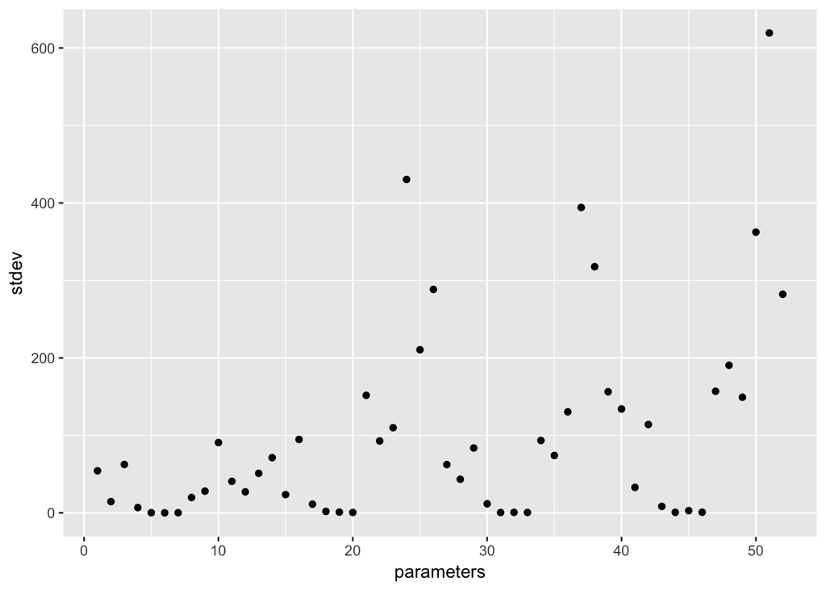

```r
qplot(data = data.frame(parameters = seq_along(sds), stdev = sds), x = parameters, y = stdev)
```

```r
norm_testing <- trim_testing
norm_training <- trim_training
for(col in 8:59) {
  colmean <- mean(trim_training[,col])
  colsd <- sd(trim_training[,col])
  norm_training[,col] <- (trim_training[,col]-colmean)/colsd
  norm_testing[,col] <- (trim_testing[,col]-colmean)/colsd
}
```

## Model building

With the normalized data, let’s proceed with the model building excercise. I would like to construct three different models using the training data, compare their performance and use the best one to predict the classes of the test dataset.

Three models chosen for the task are classification trees (C5.0), stochastic gradient boosting (gbm) and supprt vector machines with radial function (svmRadial). All three models will be built using repeated cross-validation, with number of folds, k = 6 and number of repeats = 3.

```r
library(caret)
library(kernlab)
library(C50)
library(gbm)
library(plyr)
set.seed(2501)

fitControl <- trainControl(method = "repeatedcv", number = 6, repeats = 3)
if(!file.exists("gbm-cv-6f3r.Rd")) {
  gbmFit <- train(classe ~ ., data = norm_training[,8:60],
                    method = "gbm",
                    trControl = fitControl)
} else {
  load("gbm-cv-6f3r.Rd")
}
gbmFit
```

```
## Stochastic Gradient Boosting
##
## 19622 samples
##    52 predictor
##     5 classes: 'A', 'B', 'C', 'D', 'E'
##
## No pre-processing
## Resampling: Cross-Validated (6 fold, repeated 3 times)
## Summary of sample sizes: 16353, 16352, 16351, 16352, 16351, 16351, ...
## Resampling results across tuning parameters:
##
##   interaction.depth  n.trees  Accuracy   Kappa
##   1                   50      0.7515885  0.6851074
##   1                  100      0.8219520  0.7746497
##   1                  150      0.8552648  0.8168402
##   2                   50      0.8557578  0.8172332
##   2                  100      0.9071455  0.8824965
##   2                  150      0.9318625  0.9137768
##   3                   50      0.8956276  0.8678783
##   3                  100      0.9435669  0.9285912
##   3                  150      0.9630856  0.9532951
##
## Tuning parameter 'shrinkage' was held constant at a value of 0.1
##
## Tuning parameter 'n.minobsinnode' was held constant at a value of 10
## Accuracy was used to select the optimal model using  the largest value.
## The final values used for the model were n.trees = 150,
##  interaction.depth = 3, shrinkage = 0.1 and n.minobsinnode = 10.
```

```r
if(!file.exists("svmRad-cv-6f3r.Rd")) {
  svmRadFit <- train(classe ~ ., data = norm_training[,8:60],
                    method = "svmRadial",
                    trControl = fitControl)
} else {
  load("svmRad-cv-6f3r.Rd")
}
svmRadFit
```

```
## Support Vector Machines with Radial Basis Function Kernel
##
## 19622 samples
##    52 predictor
##     5 classes: 'A', 'B', 'C', 'D', 'E'
##
## No pre-processing
## Resampling: Cross-Validated (6 fold, repeated 3 times)
## Summary of sample sizes: 16353, 16352, 16350, 16352, 16351, 16352, ...
## Resampling results across tuning parameters:
##
##   C     Accuracy   Kappa
##   0.25  0.6777220  0.5834163
##   0.50  0.8910232  0.8622841
##   1.00  0.9444499  0.9298228
##
## Tuning parameter 'sigma' was held constant at a value of 0.013981
## Accuracy was used to select the optimal model using  the largest value.
## The final values used for the model were sigma = 0.013981 and C = 1.
```

```r
if(!file.exists("C5.0-cv-6f3r.Rd")) {
  C5.0Fit <- train(classe ~ ., data = norm_training[,8:60],
                    method = "C5.0",
                    trControl = fitControl)
} else {
  load("C5.0-cv-6f3r.Rd")
}
C5.0Fit
```

```
## C5.0
##
## 19622 samples
##    52 predictor
##     5 classes: 'A', 'B', 'C', 'D', 'E'
##
## No pre-processing
## Resampling: Cross-Validated (6 fold, repeated 3 times)
## Summary of sample sizes: 16353, 16352, 16351, 16351, 16352, 16351, ...
## Resampling results across tuning parameters:
##
##   model  winnow  trials  Accuracy   Kappa
##   rules  FALSE    1      0.9682332  0.9598218
##   rules  FALSE   10      0.9939694  0.9923713
##   rules  FALSE   20      0.9959229  0.9948426
##   rules   TRUE    1      0.9688448  0.9605958
##   rules   TRUE   10      0.9943261  0.9928229
##   rules   TRUE   20      0.9960588  0.9950147
##   tree   FALSE    1      0.9646658  0.9553090
##   tree   FALSE   10      0.9936805  0.9920062
##   tree   FALSE   20      0.9953963  0.9941767
##   tree    TRUE    1      0.9650396  0.9557833
##   tree    TRUE   10      0.9933578  0.9915984
##   tree    TRUE   20      0.9951755  0.9938974
##
## Accuracy was used to select the optimal model using  the largest value.
## The final values used for the model were trials = 20, model = rules
##  and winnow = TRUE.
```

From the summaries of the models above we can see that the C5.0 model performs the best, with the average accuracy of 0.996. This allows us to estumate the out-of-sample error to 0.4%, which is very good, but may mean model overfitting. Importantly, the confusion matrix for the entire dataset (in-sample error) shows perfect classification performance (see below, the numbers are percentages).

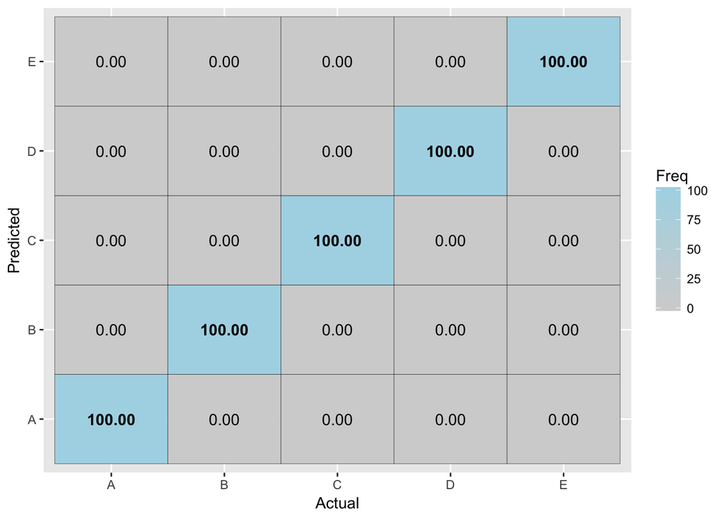

```r
pred <- predict(C5.0Fit, norm_training[8:59])
confMat <- confusionMatrix(pred, norm_training$classe)

confu <- data.frame(confMat$table)

for(f in c("A", "B", "C", "D", "E")) {
  this_class = confu$Reference == f
  confu[this_class,]$Freq = (confu[this_class,]$Freq/sum(confu[this_class,]$Freq))*100
}
confu <- cbind(confu, Diag = (confu$Prediction == confu$Reference)+2)

ggplot(aes(x = Reference, y = Prediction, fill = Freq), data = confu) +
geom_tile(color = "black", size = 0.1) + labs(x="Actual",y="Predicted") +
geom_text(aes(label=sprintf("%.2f", Freq)), data=subset(confu, as.character(Reference)!=as.character(Prediction)), colour="black") + scale_fill_gradient(low="lightgrey",high="lightblue") +
geom_text(aes(label=sprintf("%.2f", Freq), fontface = "bold"), data=subset(confu, as.character(Reference)==as.character(Prediction)), color="black")
```

Nevertheless, checking the cross-validation performance of the C5.0 model for each fold and repetition (below) shows consistency. Therefore I will predict the test set based on the C5.0 model.

```r
C5.0Fit$resample
```

```
##     Accuracy     Kappa   Resample
## 1  0.9960257 0.9949728 Fold3.Rep1
## 2  0.9975535 0.9969055 Fold2.Rep1
## 3  0.9951085 0.9938123 Fold1.Rep2
## 4  0.9960257 0.9949727 Fold6.Rep1
## 5  0.9963303 0.9953586 Fold5.Rep1
## 6  0.9972477 0.9965183 Fold3.Rep3
## 7  0.9951085 0.9938126 Fold4.Rep1
## 8  0.9969419 0.9961319 Fold2.Rep3
## 9  0.9954128 0.9941977 Fold1.Rep3
## 10 0.9954128 0.9941977 Fold6.Rep2
## 11 0.9947996 0.9934209 Fold1.Rep1
## 12 0.9963303 0.9953583 Fold5.Rep2
## 13 0.9972477 0.9965184 Fold4.Rep2
## 14 0.9975543 0.9969064 Fold3.Rep2
## 15 0.9957187 0.9945846 Fold2.Rep2
## 16 0.9960269 0.9949744 Fold6.Rep3
## 17 0.9951070 0.9938104 Fold5.Rep3
## 18 0.9951070 0.9938112 Fold4.Rep3
```